# Part II - Findings from Ford GoBike System

## by Mark Lam

## Investigation Overview

In this investigation, I'd like to see how long the average trip takes. How weekdays and weekends riding activities would differ. And finally the top 10 starting and ending spots during weekdays and weekends respectively.

## Dataset Overview

There are 183,412 bike trips in the dataset with 16 columns of information about each trip such as duration, start and end time, station information and user information. I have also added new columns like duration_min (in minutes), age of users, distance calculated by coordinates, start_hour from start_time, start day and weekend. Most variables regarding the trips are numeric in nature, but there are also variables about the riders.

## Distribution of Trip Duration

The duration from the dataset take on a large range of values, from 1 minute to 1424 minutes. Plotting on a logarithmic scale, the distribution of duration takes on a unimodal shape, with one peak between 5 to 15 minutes.

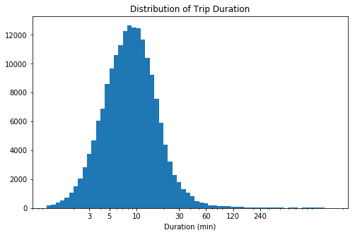

## Distribution of Start Hour on Weekdays and Weekends

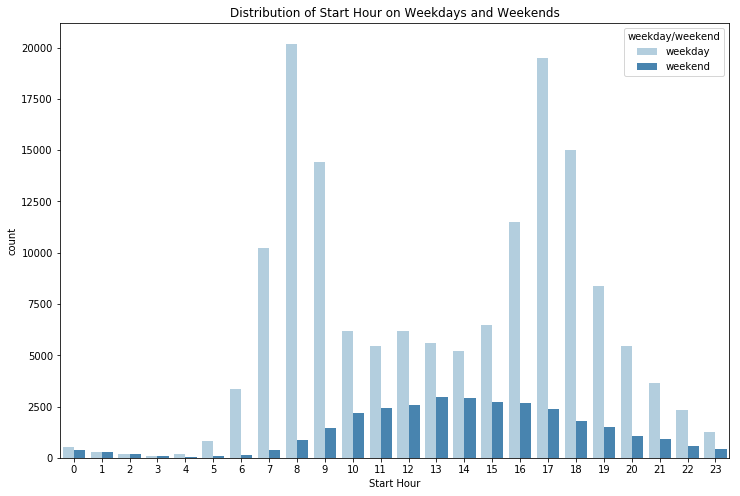

## Distribution of Top 10 Starting and Ending Spots on Weekdays

During the weekdays, the top 10 spots would be centred around the San Francisco downton. There are some overlapping spots when we consider the top 10 starting and ending spots.

[interactive chart not shown]

## Distribution of Top 10 Starting and Ending Spots on Weekends

The top 10 starting and ending spots are slightly more spreaded for weekends than weekdays. Again there are some overlapping spots when we consider the top 10 starting and ending spots.

[interactive chart not shown]